# Angewandte Forschungsprojekte

## Logistische Regression

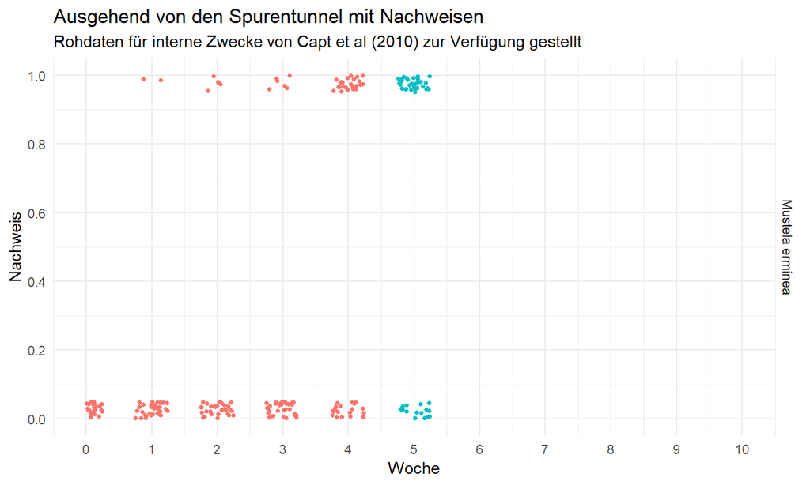

## Logistische Regression

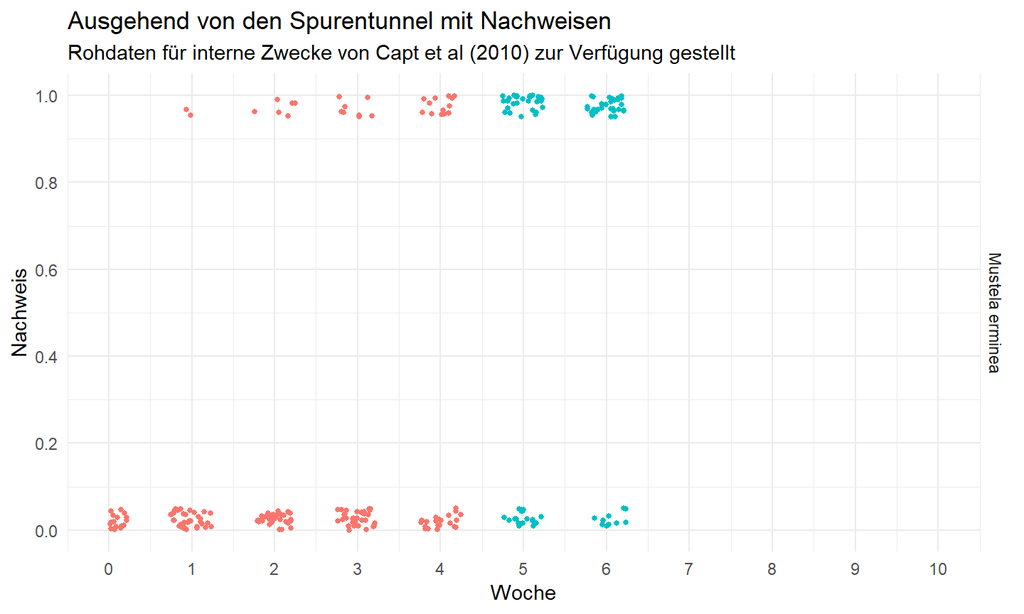

## Logistische Regression

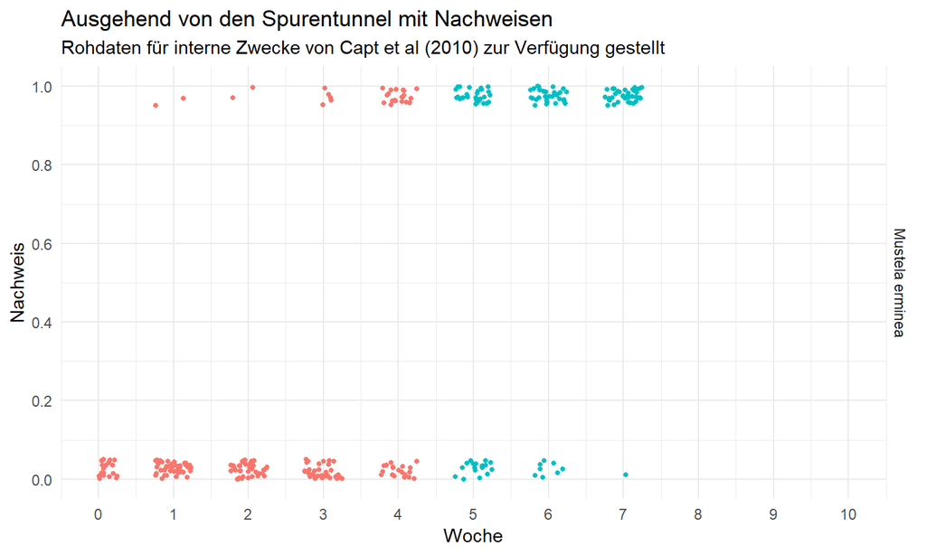

## Logistische Regression

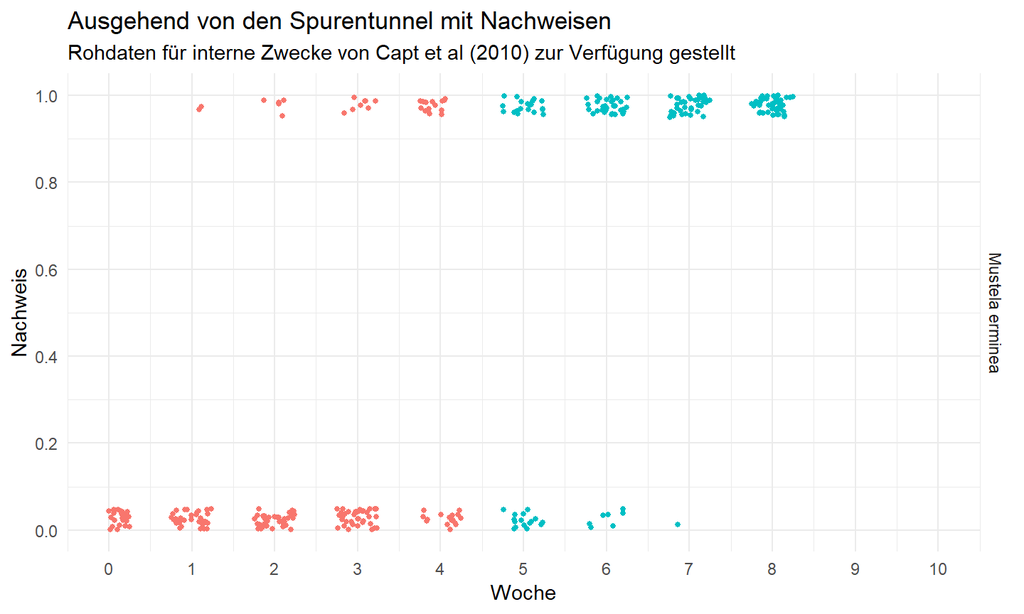

## Logistische Regression

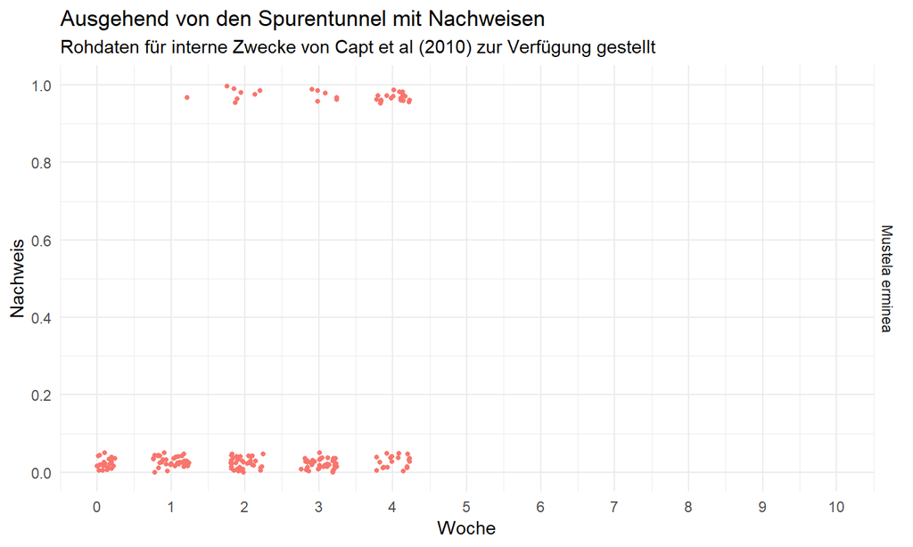

## Logistische Regression

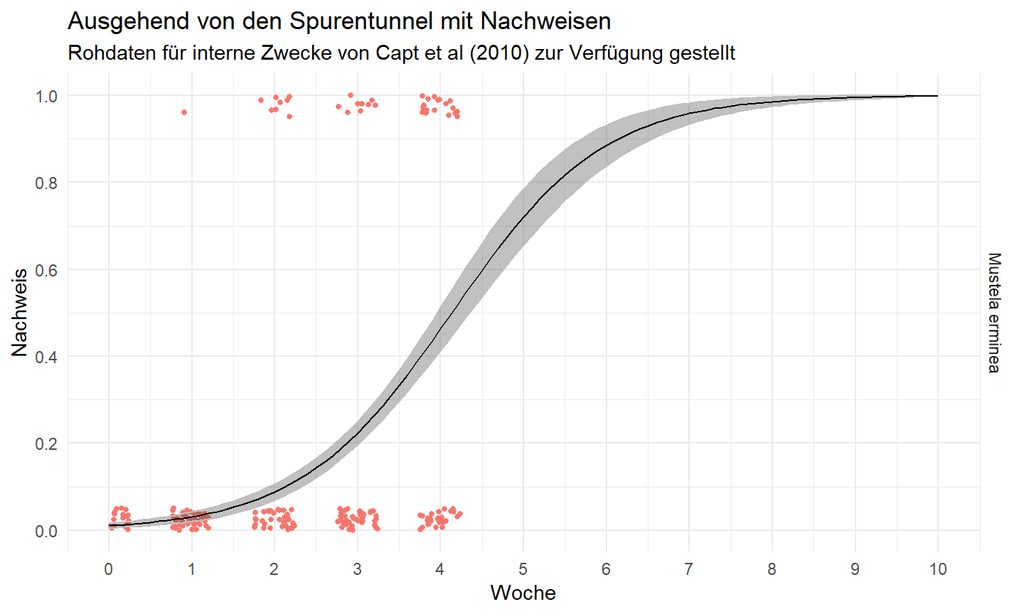

## Logistische Regression

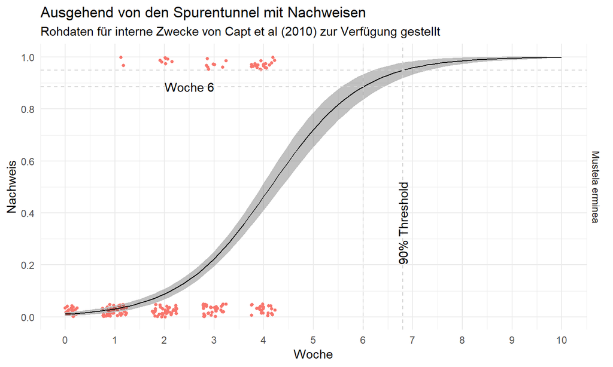

## Logistische Regression

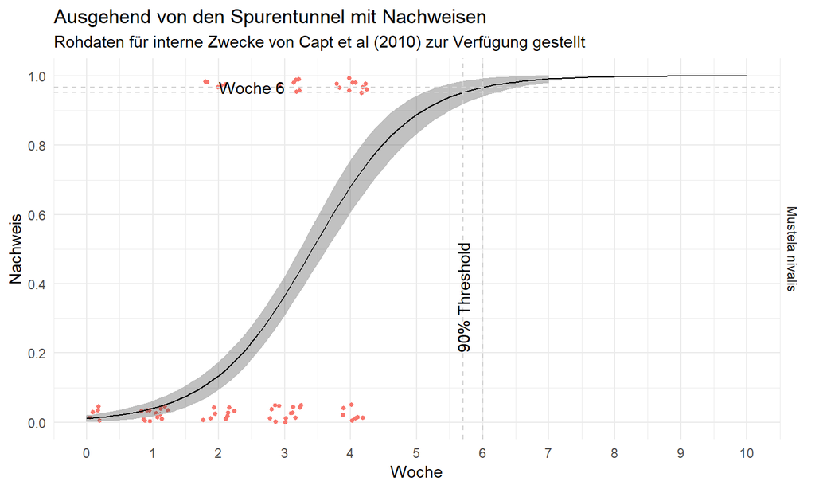

## Logistische Regression

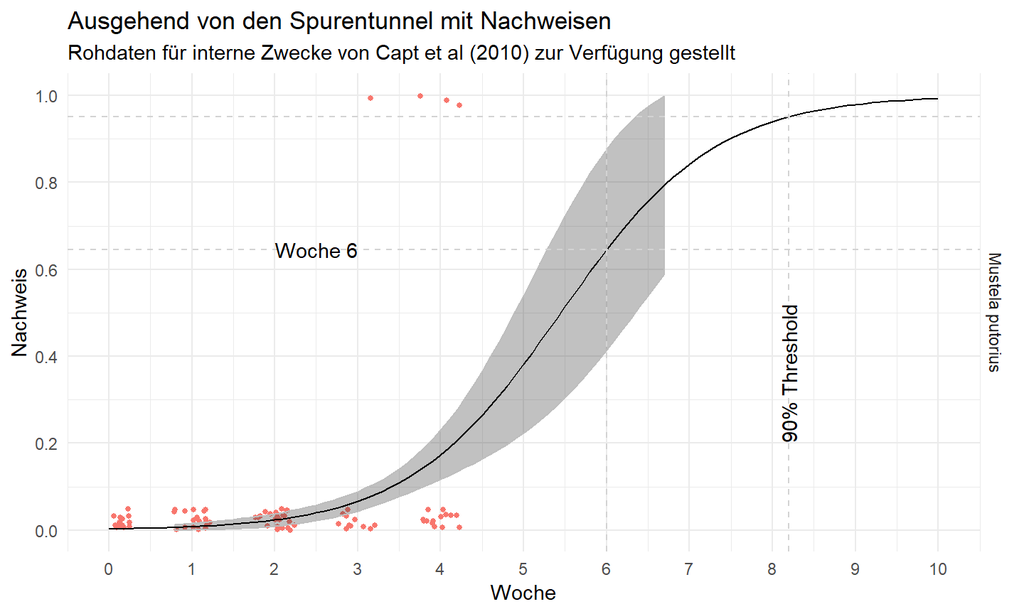

## Räumzeitliche Autokorrelation

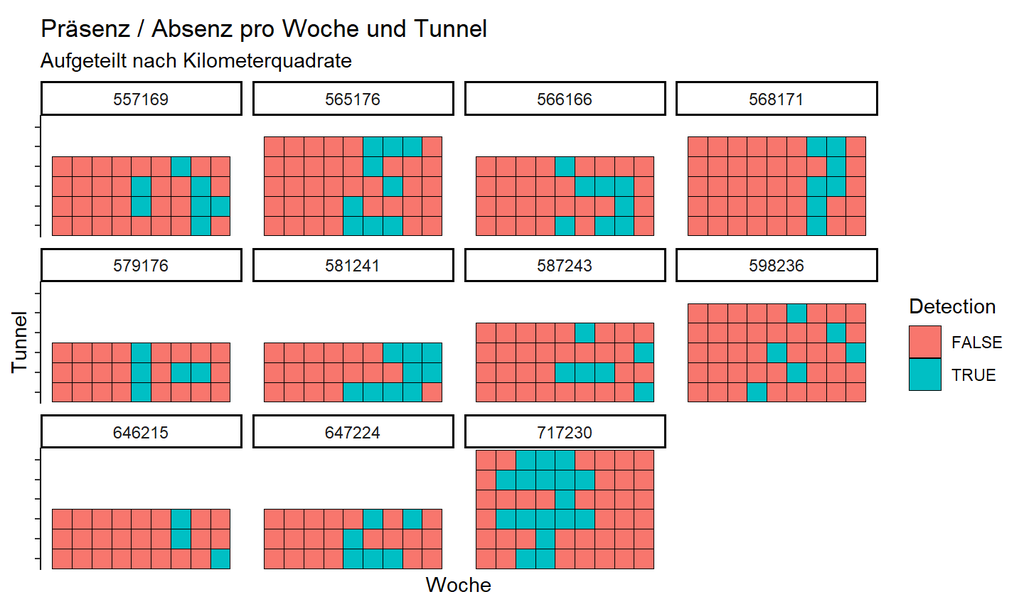

## Alternative Ansätze

[video not shown]

## Take Home Message

- Aus sauber durchgeführte Erhebungen (wie Capt et. al (2010)) lassen sich viele Erkentnisse ziehen
- Lasst uns unsere Daten zusammenführen und Erkentnisse gewinnen!
- Lasst uns die “Best practices” für die Durchführung von Wirkungskontrollen (Müri & Weinberger, 2014) erweitern um
- zukünftige Daten ebenfalls nutzen zu können
- ein neues Verfahren aufgrund der bisherigen Erfahren vorschlagen?

## Take Home Message (II)

- Datum der Inbetriebnahme notieren!
- wöchentlich im gleichen Intervall kontrollieren (nachträgliches Diskretisieren ist mit Informationsverlust behaftet)
- Leere Spurenblätter ebenfalls erfassen
- “Erfolglose” Spurentunnel ebenfalls erfassen

## Räuber-Beute Dynamik

- Rückblick TubeCam
- Schwerpunkte 2019/2020
  - Weiterentwicklung Nachweismethodik
  - Angepasstes Versuchdesign Erfolgskontrolle
  - Räuber-Beute Dynamik
  - Erhebung von Kleinstrukturen LiDAR
  - Nistkastenmonitoring

## Ausgangslage

- Wir wissen das unsere Zielarten extremen Schwankungen ausgesetzt sind.
- Diese Schwankungen werden massgeblich durch die Verfügbarkeit der Beutetieren verursacht
- Einmalig durchgeführten Erhebungen sollten demnach in den Kontext dieser Schwankungen gesetzt werden
- Bislang fehlte es an systematischen, quantitativen Erhebungen der Beutetieren
- Dies hat sich mit dem Start des Projekts “Schermausradar” geändert

## Der Schermausradar

[figure not shown]

## Mehrjahresschwankungen

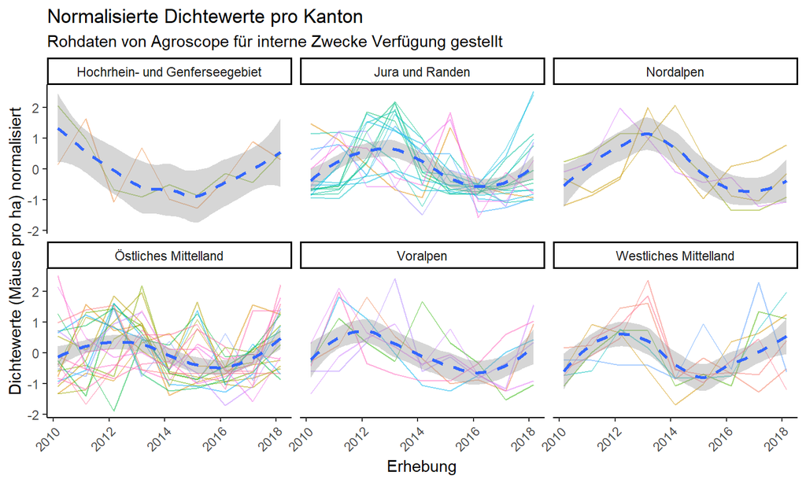

## Räumliche Verteilung

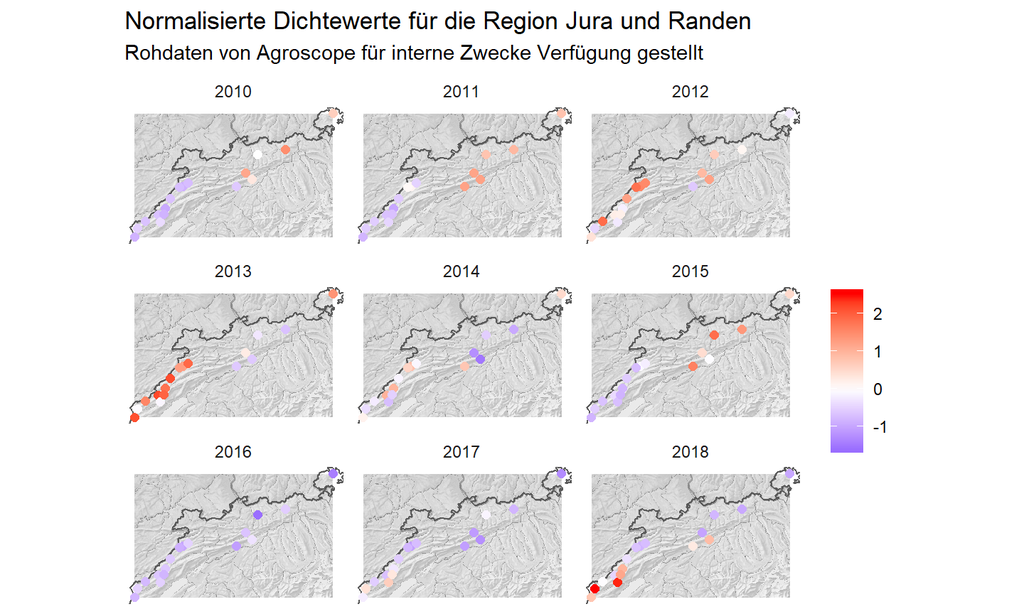

## Take Home Message

- Durch Agroscope / AGFF (Schermausradar) ist ein Datenfundus vorhanden, mit denen wir Populationsschwankungen unserer Zielarten nachvollziehen und voraussagen können
- Diese Daten könnten für die Planung oder für die Auswertung von Wirkungskontrollen genutzt werden
- Zudem gäbe es ein paar spannde Forschungsfragen, auf die man eifrige Studenten ansetzen könnte

## Erhebung von Kleinstrukturen LiDAR

- Rückblick TubeCam
- Schwerpunkte 2019/2020
  - Weiterentwicklung Nachweismethodik
  - Angepasstes Versuchdesign Erfolgskontrolle
  - Räuber-Beute Dynamik
  - Erhebung von Kleinstrukturen LiDAR
  - Nistkastenmonitoring

## Worum geht es?

Im Laufe unseres Projekts *Wiesel & Co am Zimmerberg* haben wir uns einige Fragen gestellt, über die ihr vermutlich auch schon gestolpert seid.

- Wo sind bei uns gut geeignete Wiesel Habitate?
- Wo sind die Patches und Kernpatches?
- Wo liegen die Korridore?
- Wo sind bereits ausreichen Kleinstrukturen vorhanden und wo nicht?

## Worum geht es?

Für Projekte mit einem kleinen Perimeter und/oder mit guten Ortskentnissen lassen sich diese Fragen Adhoc mit Stift und Papier beantworten.

Ist das Projektgebiet jedoch gross und/oder es fehlen entsprechende Ortskentnisse, kann eine GIS Analyse abhilfe leisten.

Bisher wurden die Bedürfnisse von Kleinraubtiere relativ schlecht in Geodaten abgebildet. Ich glaube, dies hat sich mit der Einführung von **LiDAR** Daten drastisch geändert.

## Was ist LiDAR?

[figure not shown]

## Was ist LiDAR?

- LiDAR: **Li**ght **D**etection **a**nd **R**anging
- Methode zur optischen Abstandsmessung
- Analog Radar, doch mit Laser anstelle von Radiowellen
- aus der Lichtlaufzeit der Signale wird die Entfernung zum Ort der Streuung berechnet

## Warum soll LiDAR von Intersse sein?

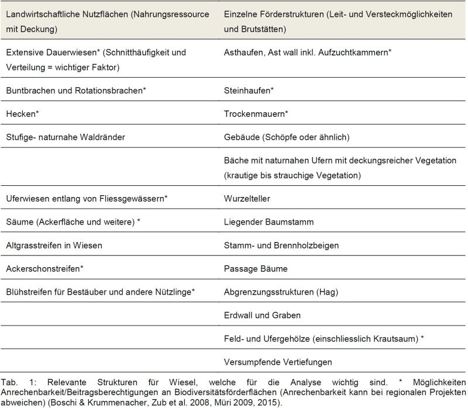

## Wie ist LiDAR verfügbar?

- Aktuell werden die Daten Kantonal erhoben
- Unterschiedliche Verfügbarkeit (frei, kostenpflichtig, nicht auffindbar)
- Unterschiedliche Qualität (Genauigkeit, Auflösung)
- Zusammenstellung nach einer kurzen Recherche:

## Wie ist LiDAR verfügbar?

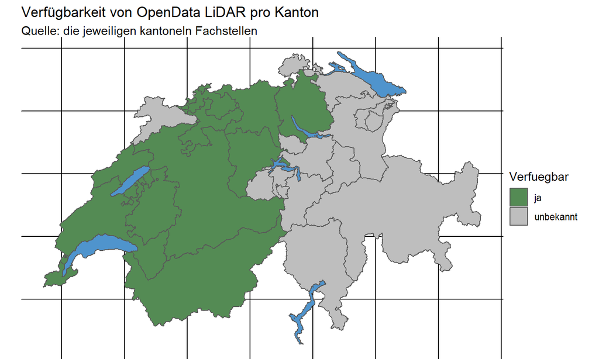

## Wie ist LiDAR verfügbar?

- Seit 2017 läuft eine schweizweite Messkampagne
- Punktdichte: 5 bis max 10 Punkte pro m2
- Lagegenauigkeit: 20 cm, Höhengenauigkeit: 10 cm
- Aktueller Zeitplan

## Wie ist LiDAR verfügbar?

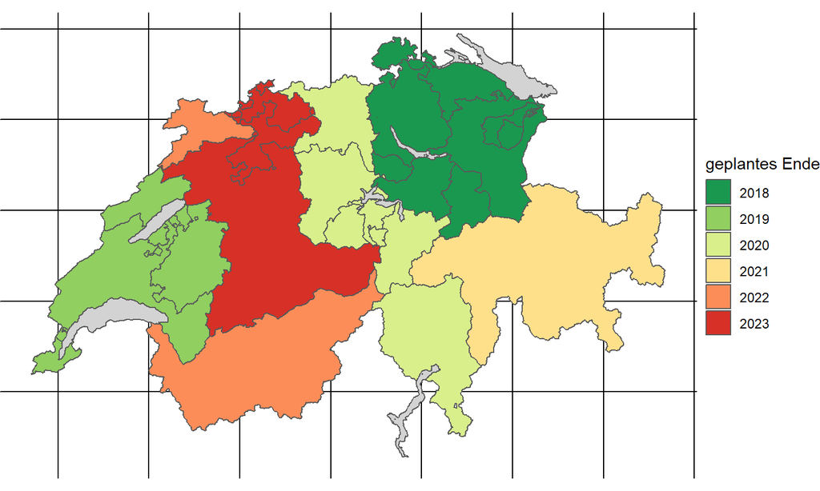

## Fallbeispiel

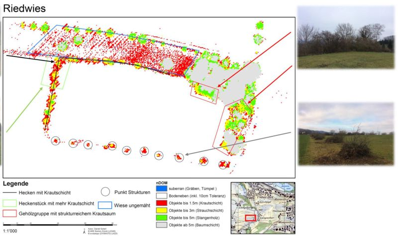

## Fallbeispiel

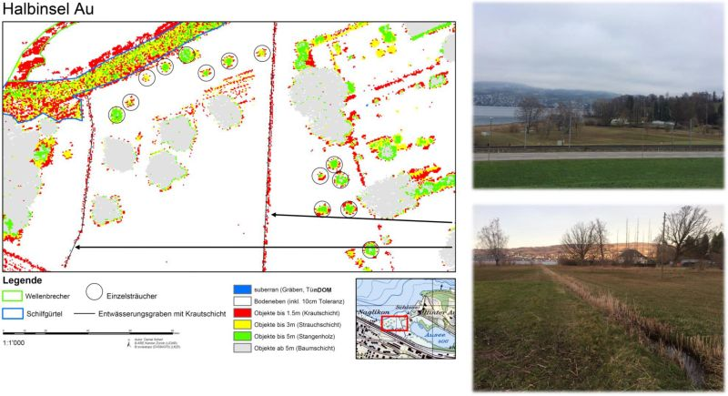

## Take Home Message

- LiDAR Daten sind bald schweizweit in einheitlicher Qualität verfügbar
- LiDAR sowie ihre abgeleiteten Produkte bieten grosses Potential für das Verständnis unserer Zielarten und der Landschaft, in der sie leben

## Nistkastenmonitoring

- Rückblick TubeCam
- Schwerpunkte 2019/2020
  - Weiterentwicklung Nachweismethodik
  - Angepasstes Versuchdesign Erfolgskontrolle
  - Räuber-Beute Dynamik
  - Erhebung von Kleinstrukturen LiDAR
  - Nistkastenmonitoring

## Ein paar Eindrücke

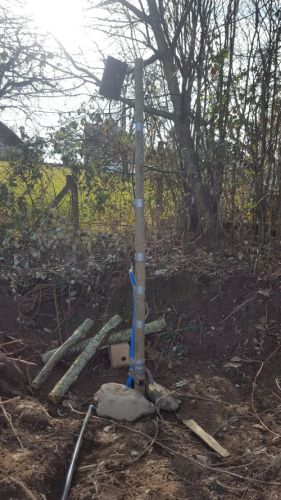

## Ein paar Eindrücke

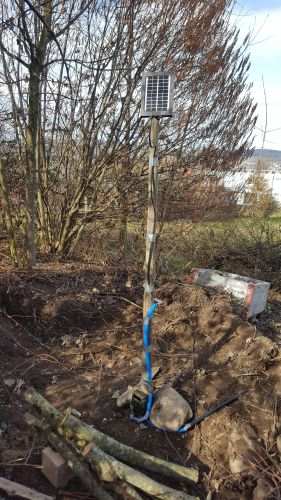

## Ein paar Eindrücke

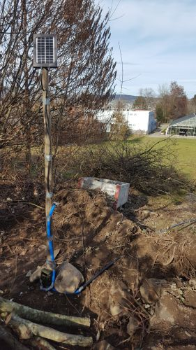